# PCA와 LDA

### 필요 패키지 import

- %matplotlib inline : jupyter 화면 안에서 그래프 시각화 결과물을 확인하기 위한 설정
- matplotlib.pyplot : pyplot은 데이터 시각화를 제공하는 패키지
- seaborn : seaborn에서 제공하는 시각화 효과를 사용하기 위한 패키지
- datasets : datasets를 통해 scikit learn이 제공하는 데이터 셋을 사용가능
- PCA : PCA를 실행하기 위한 패키지
- LinearDiscriminantAnalysis : LDA를 실행하기 위한 패키지
- train_test_split : train set과 test set으로 데이터 셋을 분리하기 위한 패키지
- RandomForestClassifier : Random Forest 분류기를 사용하기 위한 패키지
- confusion_matrix : 성능 평가시 confusion matrix를 확인하기 위한 패키지
- classification_report : 클래스별 성능을 확인하기 위한 패키지
- f1_score : 모델의 f-measure을 확인하기 위한 패키지
- accuracy_score : 모델의 accuracy를 확인하기 위한 패키지
- time : 모델의 속도를 측정하기 위한 패키지
- pandas : 데이터 프레임을 사용하기 위한 패키지

```python
%matplotlib inline
import matplotlib.pyplot as plt
import seaborn as sns

from sklearn import datasets
from sklearn.decomposition import PCA
from sklearn.discriminant_analysis import LinearDiscriminantAnalysis
from sklearn.model_selection import train_test_split

from sklearn.ensemble import RandomForestClassifier

from sklearn.metrics import confusion_matrix
from sklearn.metrics import classification_report
from sklearn.metrics import f1_score
from sklearn.metrics import accuracy_score
import time

import pandas as pd
```

### 데이터 셋 준비

- scikit learn에서 제공하는 toy data 중 붓꽃 데이터를 load_iris 함수를 사용해 로드하고, 변수 data에 저장
- len 함수를 사용해 속성의 개수를 확인
- feature_names : 속성들의 종류를 확인
- target_names : 클래스 종류를 확인

```python
data = datasets.load_iris()
print(len(data.feature_names))
print(data.feature_names)
print(len(data.target_names))
print(data.target_names)
```

```
4
['sepal length (cm)', 'sepal width (cm)', 'petal length (cm)', 'petal width (cm)']
3
['setosa' 'versicolor' 'virginica']
```

### 성능 기록 준비

- 컬럼이 Data Set, F-Measure, Accuracy, Speed (sec) 로 이루어진 데이터 프레임 df_per을 생성해 성능을 기록할 준비

```python
df_per = pd.DataFrame(columns=['Data Set', 'F-Measure', 'Accuracy', 'Speed (sec)'])
df_per
```

|  | Data Set | F-Measure | Accuracy | Speed (sec) |
| --- | --- | --- | --- | --- |

# 1. 원본 데이터 살펴보기

### 1.1 데이터 셋 준비

- 데이터의 속성 중 첫 번째, 두 번째 속성 두 가지만 선택해 변수 x에 저장
- 즉, sepal length와 sepal width가 저장
- 종(setosa, versicolor, virginica)을 나타내는 클래스 정보를 target 함수를 사용해 가져와 변수 y에 저장
- 클래스 정보를 변수 target_names에 저장

```python
x = data.data[:, :2]
y = data.target
target_names = data.target_names
target_names
```

```
array(['setosa', 'versicolor', 'virginica'],
      dtype='<U10')
```

### 1.2 산포도 그리기

- 산포도를 그리기 위한 figure의 크기를 설정
- 클래스마다 색상을 다르게 표시하기 위해 색상을 붉은색과 푸른색으로 설정
- for문을 사용해 데이터를 산포도에 그림
- 색상[red,blue]과, 클래스[0,1], 클래스 이름[setosa,versicolor]을 내장함수 zip으로 묶음
- zip함수를 사용하면 동일한 개수로 이루어진 자료형을 묶을 수 있음
- 각 색상, 클래스, 클래스 이름에 대한 데이터를 하나씩 산포도로 그림
- scatter 함수를 사용해 속성 x의 클래스 y가 i 즉, 0 또는 1인지 확인 후,
- x의 0번 속성을 x축 값, 1번 속성을 y축 값으로 지정하고
- 해당 클래스 인덱스에 해당하는 색상으로 표시하고
- 라벨을 클래스 이름으로 설정
- legend 함수를 사용해 도표 설명(legend)을 표시
- xlabel 함수를 사용해 x축 이름 sepal length (cm)를 표시
- ylabel 함수를 사용해 y축 이름 sepal width (cm)를 표시
- show 함수를 사용해 산포도 시각화

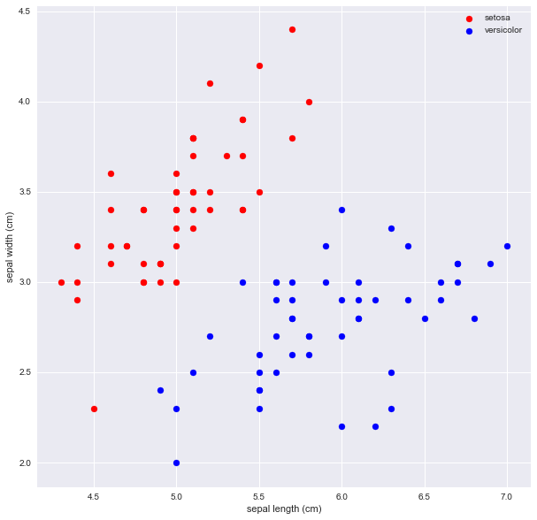

```python
plt.figure(figsize=(10, 10))
colors = ['red', 'blue']

for color, i, target_name in zip(colors, [0, 1], target_names):
    plt.scatter(x[y == i, 0], x[y == i, 1], color=color, label=target_name)

plt.legend()
plt.xlabel('sepal length (cm)')
plt.ylabel('sepal width (cm)')
plt.show()
```

### 1.3 분류

- 붓꽃 종을 나타내는 클래스 정보를 target 함수를 사용해 가져와 변수 y에 저장
- x, y 데이터에 대해 train : test = 8 : 2 로 구분
- train set : X_train, Y_train
- test set : X_test, Y_test

```python
x = data.data
y = data.target
X_train, X_test, Y_train, Y_test = train_test_split(x, y, test_size=0.2)
```

- start : 현재 시간을 시작 시간으로 기록
- RandomForestClassifier를 사용해 분류 모델 estimator 생성, 200개의 tree 사용
- fit 함수를 사용해 train data를 훈련
- predict 함수를 사용해 X_test 에 대한 분류 결과 추출하고, Y_pred에 저장
- end : 현재 시간에서 시작 시간을 뺀 수행 시간을 end에 저장
- 실제값 Y_test와 예측값 Y_pred를 비교한 성능 평가 결과 출력 : confusion matrix, classification report, accuracy, f-measure, speed
- 데이터 프레임에 성능 기록

```python
start = time.time()
estimator = RandomForestClassifier(n_estimators=200)
estimator.fit(X_train, Y_train)
Y_pred = estimator.predict(X_test)
end = time.time() - start

print('\n Confusion Matrix \n')
print(confusion_matrix(Y_test, Y_pred))
print('\n Classification Report \n')
print(classification_report(Y_test, Y_pred))
print('\n Accuracy \n')
ac = round(accuracy_score(Y_test, Y_pred, normalize=True), 2)
print(ac)
print('\n F-Measure \n')
fm = round(f1_score(Y_test, Y_pred, average='weighted'), 2)
print(fm)
print('\n Speed \n')
print('%.02f second' %end)

df_per.loc[len(df_per)] = ['Original', fm, ac, float('%.02f' %end)]
df_per
```

```
 Confusion Matrix

[[ 8  0  0]
 [ 0  7  3]
 [ 0  0 12]]

 Classification Report

             precision    recall  f1-score   support

          0       1.00      1.00      1.00         8
          1       1.00      0.70      0.82        10
          2       0.80      1.00      0.89        12

avg / total       0.92      0.90      0.90        30


 Accuracy

0.9

 F-Measure

0.9

 Speed

0.19 second
```

|  | Data Set | F-Measure | Accuracy | Speed (sec) |
| --- | --- | --- | --- | --- |
| 0 | Original | 0.9 | 0.9 | 0.19 |

# 2. PCA

### 2.1 데이터 셋 준비

- 데이터의 속성들을 변수 x에 저장
- 클래스 정보를 target 함수를 사용해 가져와 변수 y에 저장
- 종 정보를 변수 target_names에 저장

```python
x = data.data
y = data.target
target_names = data.target_names
```

### 2.2 PCA 모델 생성

- PCA 라이브러리를 사용해 주성분 분석을 위한 모듈 pca를 생성
- 주성분을 두 개 추출하기 위해 n_components를 2로 설정
- 속성 데이터 x와 fit 함수를 사용해 pca 모델을 훈련시키고
- transform 함수를 사용해 차원 축소를 진행
- 차원 축소 결과를 변수 x_p에 저장
- 모델 pca에 의해 추출된 주성분 두 개의 분산을 출력

```python
pca = PCA(n_components=2)
x_p = pca.fit(x).transform(x)
print('가장 큰 주성분 두 개에 대한 분산: %s' % str(pca.explained_variance_ratio_))
```

```
가장 큰 주성분 두 개에 대한 분산: [ 0.92461621  0.05301557]
```

### 2.3 산포도 그리기

- 산포도를 그리기 위한 figure의 크기를 설정
- 클래스마다 색상을 다르게 표시하기 위해 색상을 붉은색과 푸른색으로 설정
- for문을 사용해 데이터를 산포도에 그림
- 색상[red,blue]과, 클래스[0,1], 클래스 이름[setosa,versicolor]을 내장함수 zip으로 묶음
- zip함수를 사용하면 동일한 개수로 이루어진 자료형을 묶을 수 있음
- 각 색상, 클래스, 클래스 이름에 대한 데이터를 하나씩 산포도로 그림
- scatter 함수를 사용해 주성분 x_p의 클래스 y가 i 즉, 0 또는 1인지 확인 후,
- x_p의 0번 속성을 x축 값, 1번 속성을 y축 값으로 지정하고
- 해당 클래스 인덱스에 해당하는 색상으로 표시하고
- 라벨을 클래스 이름으로 설정
- legend 함수를 사용해 도표 설명(legend)을 표시
- xlabel 함수를 사용해 x축 이름 PC(Principal Component)1를 표시
- ylabel 함수를 사용해 y축 이름 PC(Principal Component)2를 표시
- show 함수를 사용해 산포도 시각화

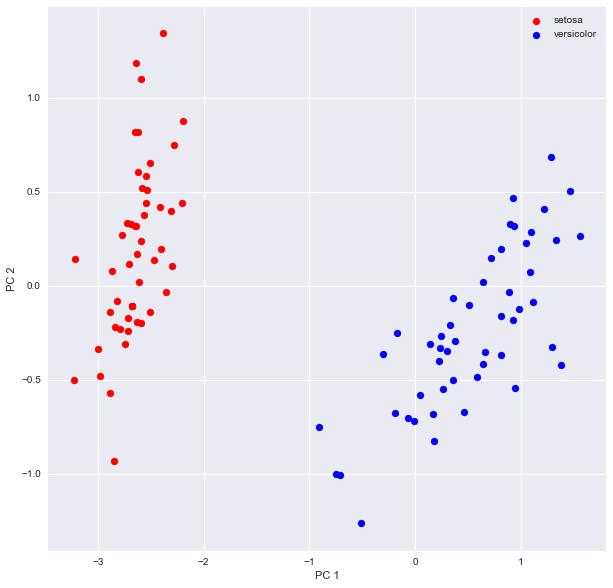

```python
plt.figure(figsize=(10, 10))
colors = ['red', 'blue']

for color, i, target_name in zip(colors, [0, 1], target_names):
    plt.scatter(x_p[y == i, 0], x_p[y == i, 1], color=color, label=target_name)

plt.legend()
plt.xlabel('PC 1')
plt.ylabel('PC 2')
plt.show()
```

### 2.4 분류

```python
pca = PCA(n_components=2)
x_p = pca.fit(x).transform(x)
X_train, X_test, Y_train, Y_test = train_test_split(x_p, y, test_size=0.2)
```

- start : 현재 시간을 시작 시간으로 기록
- RandomForestClassifier를 사용해 분류 모델 estimator 생성, 200개의 tree 사용
- fit 함수를 사용해 train data를 훈련
- predict 함수를 사용해 X_test 에 대한 분류 결과 추출하고, Y_pred에 저장
- end : 현재 시간에서 시작 시간을 뺀 수행 시간을 end에 저장
- 실제값 Y_test와 예측값 Y_pred를 비교한 성능 평가 결과 출력 : confusion matrix, classification report, accuracy, f-measure, speed
- 데이터 프레임에 성능 기록

```python
start = time.time()
estimator = RandomForestClassifier(n_estimators=200)
estimator.fit(X_train, Y_train)
Y_pred = estimator.predict(X_test)
end = time.time() - start

print('\n Confusion Matrix \n')
print(confusion_matrix(Y_test, Y_pred))
print('\n Classification Report \n')
print(classification_report(Y_test, Y_pred))
print('\n Accuracy \n')
ac = round(accuracy_score(Y_test, Y_pred, normalize=True), 2)
print(ac)
print('\n F-Measure \n')
fm = round(f1_score(Y_test, Y_pred, average='weighted'), 2)
print(fm)
print('\n Speed \n')
print('%.02f second' %end)

df_per.loc[len(df_per)] = ['PCA', fm, ac, float('%.02f' %end)]
df_per
```

```
 Confusion Matrix

[[ 7  0  0]
 [ 0 10  0]
 [ 0  4  9]]

 Classification Report

             precision    recall  f1-score   support

          0       1.00      1.00      1.00         7
          1       0.71      1.00      0.83        10
          2       1.00      0.69      0.82        13

avg / total       0.90      0.87      0.87        30


 Accuracy

0.87

 F-Measure

0.87

 Speed

0.23 second
```

|  | Data Set | F-Measure | Accuracy | Speed (sec) |
| --- | --- | --- | --- | --- |
| 0 | Original | 0.90 | 0.90 | 0.19 |
| 1 | PCA | 0.87 | 0.87 | 0.23 |

# 3. LDA

### 3.1 데이터 셋 준비

- 데이터의 속성들을 변수 x에 저장
- 클래스 정보를 target 함수를 사용해 가져와 변수 y에 저장
- 클래스 명을 변수 target_names에 저장

```python
x = data.data
y = data.target
target_names = data.target_names
```

### 3.2 LDA 모델 생성

```python
lda = LinearDiscriminantAnalysis(n_components=2)
x_l = lda.fit(x, y).transform(x)
```

### 3.3 산포도 그리기

- 산포도를 그리기 위한 figure의 크기를 설정
- 클래스마다 색상을 다르게 표시하기 위해 색상을 붉은색과 푸른색으로 설정
- for문을 사용해 데이터를 산포도에 그림
- 색상[red,blue]과, 클래스[0,1], 클래스 이름[setosa,versicolor]을 내장함수 zip으로 묶음
- zip함수를 사용하면 동일한 개수로 이루어진 자료형을 묶을 수 있음
- 각 색상, 클래스, 클래스 이름에 대한 데이터를 하나씩 산포도로 그림
- scatter 함수를 사용해 주성분 x_l의 클래스 y가 i 즉, 0 또는 1인지 확인 후,
- x_l의 0번 속성을 x축 값, 1번 속성을 y축 값으로 지정하고
- 해당 클래스 인덱스에 해당하는 색상으로 표시하고
- 라벨을 클래스 이름으로 설정
- legend 함수를 사용해 도표 설명(legend)을 표시
- xlabel 함수를 사용해 x축 이름 LD1를 표시
- ylabel 함수를 사용해 y축 이름 LD2를 표시
- show 함수를 사용해 산포도 시각화

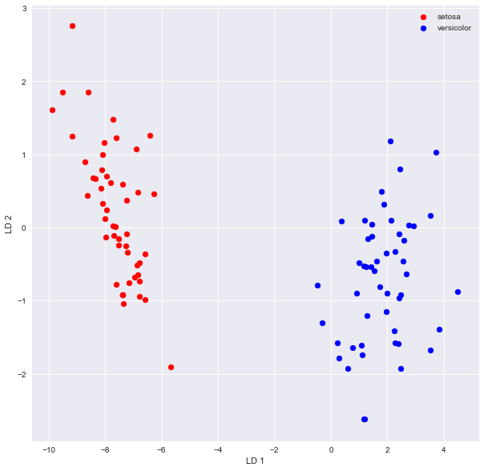

```python
plt.figure(figsize=(10, 10))
colors = ['red', 'blue']

for color, i, target_name in zip(colors, [0, 1], target_names):
    plt.scatter(x_l[y == i, 0], x_l[y == i, 1], color=color, label=target_name)

plt.legend()
plt.xlabel('LD 1')
plt.ylabel('LD 2')
plt.show()
```

### 3.4 분류

```python
lda = LinearDiscriminantAnalysis(n_components=2)
x_l = lda.fit(x, y).transform(x)
X_train, X_test, Y_train, Y_test = train_test_split(x_l, y, test_size=0.2)
```

- start : 현재 시간을 시작 시간으로 기록
- RandomForestClassifier를 사용해 분류 모델 estimator 생성, 200개의 tree 사용
- fit 함수를 사용해 train data를 훈련
- predict 함수를 사용해 X_test 에 대한 분류 결과 추출하고, Y_pred에 저장
- end : 현재 시간에서 시작 시간을 뺀 수행 시간을 end에 저장
- 실제값 Y_test와 예측값 Y_pred를 비교한 성능 평가 결과 출력 : confusion matrix, classification report, accuracy, f-measure, speed
- 데이터 프레임에 성능 기록

```python
start = time.time()
estimator = RandomForestClassifier(n_estimators=200)
estimator.fit(X_train, Y_train)
Y_pred = estimator.predict(X_test)
end = time.time() - start

print('\n Confusion Matrix \n')
print(confusion_matrix(Y_test, Y_pred))
print('\n Classification Report \n')
print(classification_report(Y_test, Y_pred))
print('\n Accuracy \n')
ac = round(accuracy_score(Y_test, Y_pred, normalize=True), 2)
print(ac)
print('\n F-Measure \n')
fm = round(f1_score(Y_test, Y_pred, average='weighted'), 2)
print(fm)
print('\n Speed \n')
print('%.02f second' %end)

df_per.loc[len(df_per)] = ['LDA', fm, ac, float('%.02f' %end)]
df_per
```

```
 Confusion Matrix

[[10  0  0]
 [ 0 13  0]
 [ 0  0  7]]

 Classification Report

             precision    recall  f1-score   support

          0       1.00      1.00      1.00        10
          1       1.00      1.00      1.00        13
          2       1.00      1.00      1.00         7

avg / total       1.00      1.00      1.00        30


 Accuracy

1.0

 F-Measure

1.0

 Speed

0.22 second
```

|  | Data Set | F-Measure | Accuracy | Speed (sec) |
| --- | --- | --- | --- | --- |
| 0 | Original | 0.90 | 0.90 | 0.19 |
| 1 | PCA | 0.87 | 0.87 | 0.23 |
| 2 | LDA | 1.00 | 1.00 | 0.22 |

# 4.성능 비교

- 시각화를 위해 데이터 셋 종류를 index로 지정

```python
df_per_1 = df_per.set_index('Data Set')
df_per_1
```

| Data Set | F-Measure | Accuracy | Speed (sec) |
| --- | --- | --- | --- |
| Original | 0.90 | 0.90 | 0.19 |
| PCA | 0.87 | 0.87 | 0.23 |
| LDA | 1.00 | 1.00 | 0.22 |

- F-measure, Accuracy, Speed (sec) 값을 plot 함수를 사용해 시각화
- kind='bar' : 막대 그래프
- title='preformance' : 그래프 제목
- figsize : 그래프 크기 지정
- legend : 데이터 설명
- fontsize : 글씨 크기
- 그래프의 x축을 'Data Set' 이름으로 지정
- 그래프의 각 객체 patch에 대해 데이터 레이블을 입력
- annotate 함수를 사용해 입력할 값과 그래프 상 위치(x, y)를 지정
- 그래프 그리기

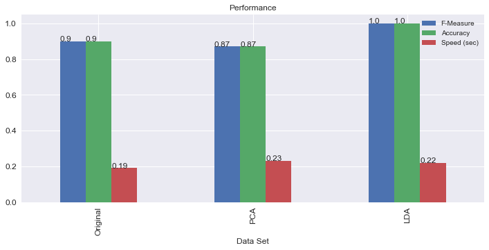

```python
ax = df_per_1[['F-Measure', 'Accuracy', 'Speed (sec)']].plot(kind='bar', title ='Performance',\
                                                             figsize=(12, 5), legend=True, fontsize=12)
ax.set_xlabel('Data Set', fontsize=12)

for p in ax.patches:
    ax.annotate(p.get_height(), (p.get_x(), p.get_height()))

plt.show()
```